# Exploratory Analysis

Addison McGhee

2021-10-08

### Read in data and create factors

```r
dat = read_csv("heart.csv")
dataset_wfactors = dat %>% mutate(anaemia = factor(anaemia),
                             diabetes = factor(diabetes),
                             high_blood_pressure = factor(high_blood_pressure),
                             sex = factor(sex),
                             smoking = factor(smoking),
                             DEATH_EVENT = factor(DEATH_EVENT)
                             )

# Dataset without factors
dataset = dataset_wfactors %>% select(-c(anaemia, diabetes, high_blood_pressure, sex, smoking, DEATH_EVENT))
```

**As with any exploratory analysis, the first step is to determine which variable are categorical, and which are continuous. We see that there are 6 categorical variables in this dataset. They were converted to `factors` to ensure ease of use with $R's$ functions.**

## Missing Values

```r
apply(dataset_wfactors, 2, FUN = function(x) sum(is.na(x)))
```

```
##                      age                  anaemia creatinine_phosphokinase
##                        0                        0                        0
##                 diabetes        ejection_fraction      high_blood_pressure
##                        0                        0                        0
##                platelets         serum_creatinine             serum_sodium
##                        0                        0                        0
##                      sex                  smoking                     time
##                        0                        0                        0
##              DEATH_EVENT
##                        0
```

**The next step was to screen for missing values as many $R$ functions cannot handle NAs. In addition, missing values can be due to underlying issues with the treatment and/or data collection procedure. Fortunately, the data does not have any missingness.**

## Summary Stats

### Continuous Correlation Matrix

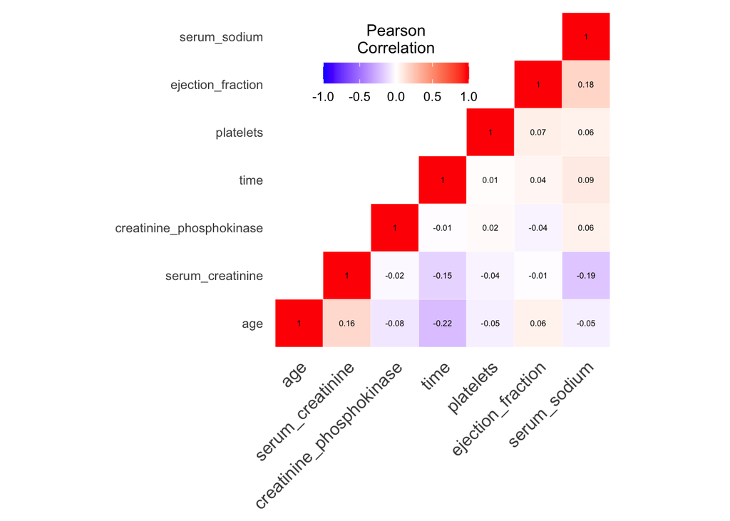

**The above graphic indicates positive and negative associations between variables. There also is a clear clustering among certain variables that share a common direction of association. We notice moderate negative relationshps between time/age, time/serum_creatinine, and serum_sodium/serum_creatinine. Our next step will be to gain additional insight into the biological mechanisms that explain why certain variables associate with each other.**

## Histograms

### Continuous Variables

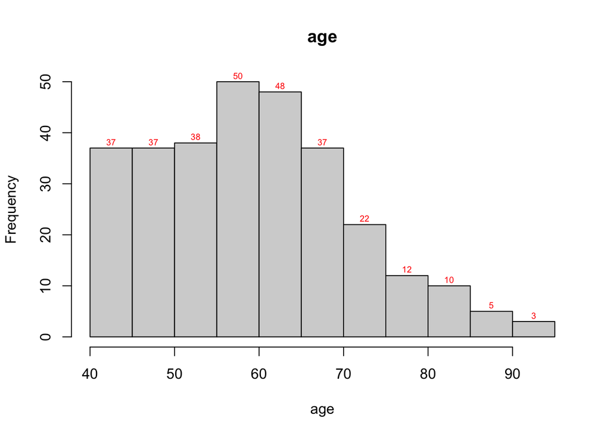

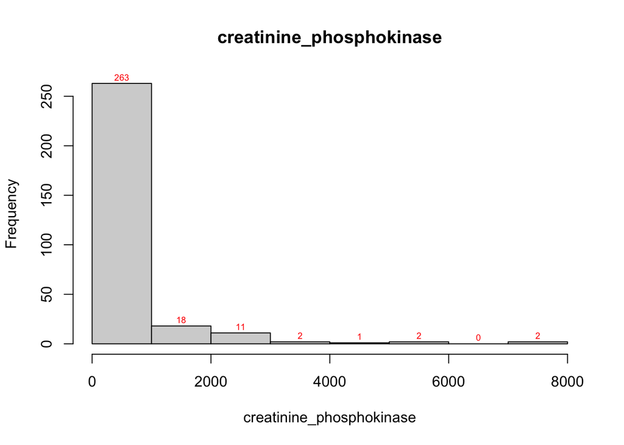

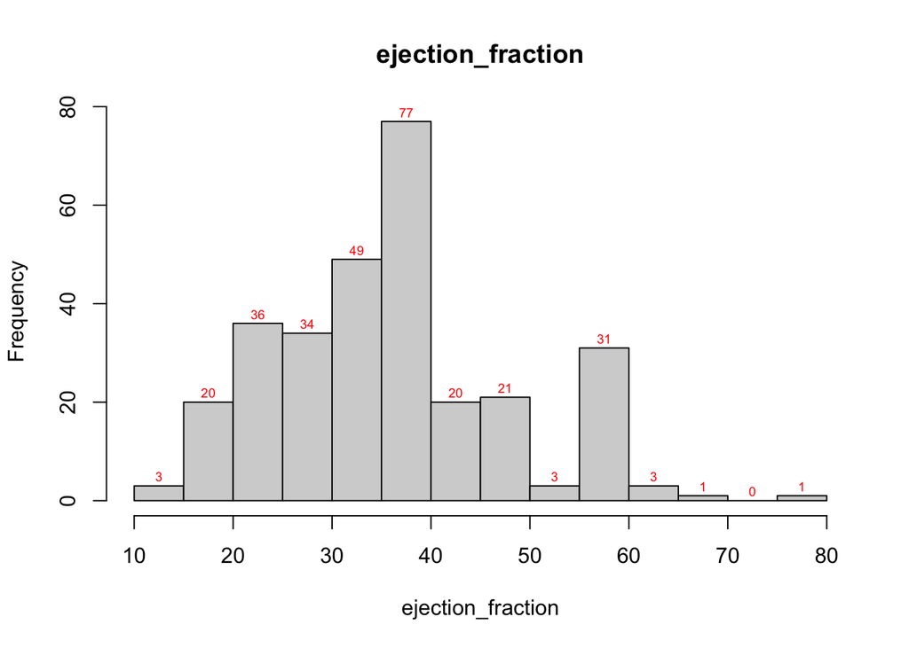

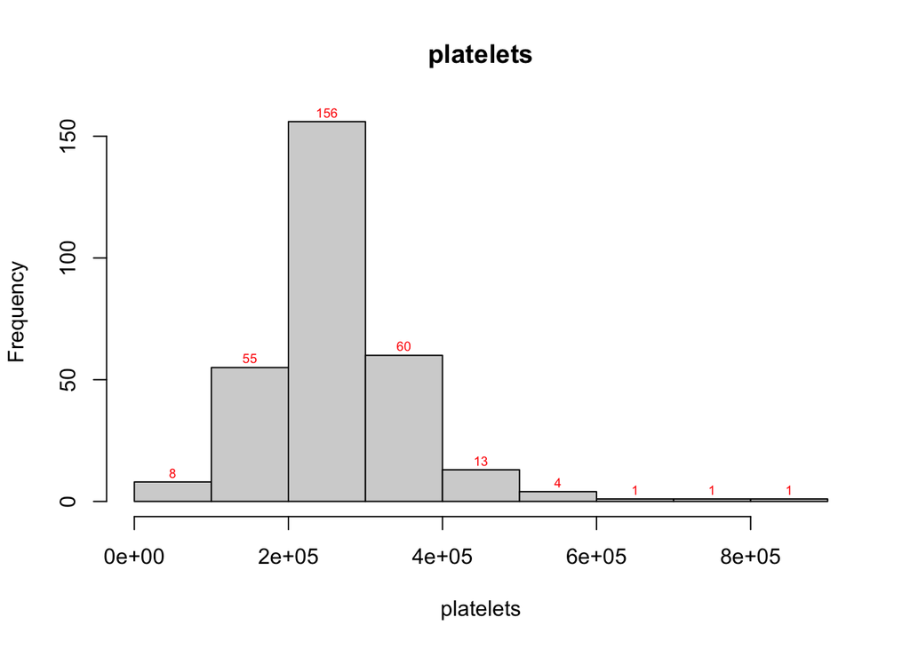

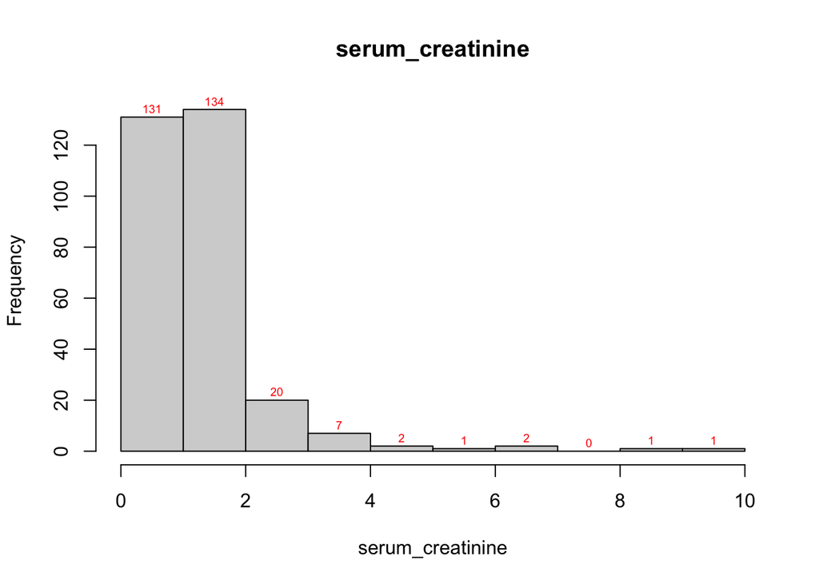

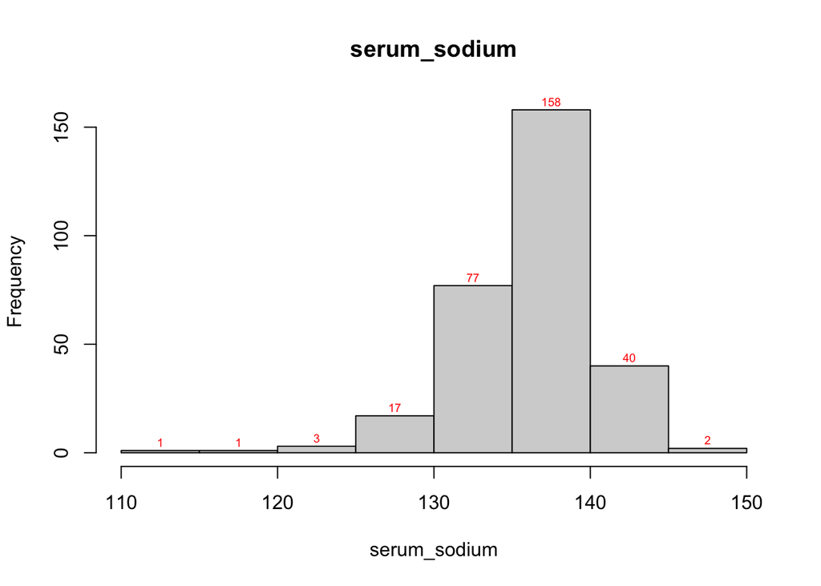

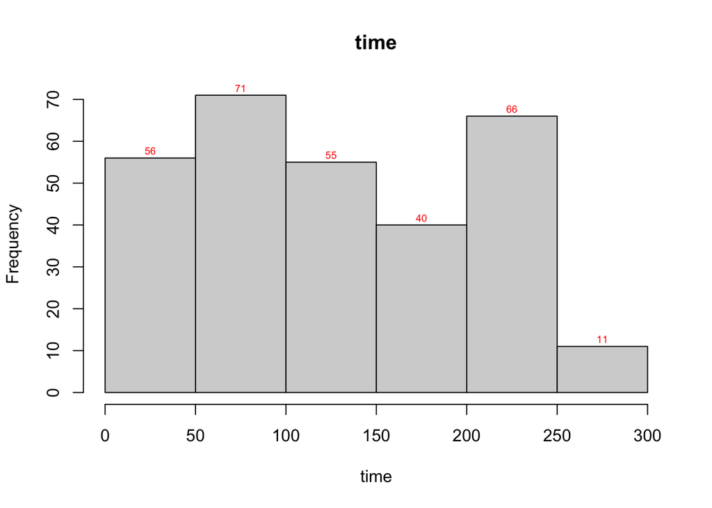

```r
do = data.frame(dataset)
for(i in 1:ncol(do)) {
    h = hist(do[, i], main = names(do)[i], xlab = names(do)[i])
    text(h$mids,h$counts,labels=h$counts, adj=c(0.5, -0.5), cex = 0.6, col = "red")
}
```

**The histograms showcase the different distributions present in the data. The variables of serum_creatinine, creatinine_phosphokinase, and age have a right-skew, while serum_sodium, platelets, and ejection_fraction are more normally distributed. The variable time is more uniformly distributed. Again, more domain knowledge will give us a better understanding of the typical distributions that these variables take. This will be useful in helping us gauge the generalizability of our results.**

### Factors

```r
dataset_wfactors %>% select(c(anaemia, diabetes, high_blood_pressure, sex, smoking, DEATH_EVENT)) %>% apply(2, table) %>% pander
```

|  | anaemia | diabetes | high_blood_pressure | sex | smoking | DEATH_EVENT |
| --- | --- | --- | --- | --- | --- | --- |
| **0** | 170 | 174 | 194 | 105 | 203 | 203 |
| **1** | 129 | 125 | 105 | 194 | 96 | 96 |

```r
dataset_wfactors %>% group_by(sex) %>% count(DEATH_EVENT) %>% pander
```

| sex | DEATH_EVENT | n |
| --- | --- | --- |
| 0 | 0 | 71 |
| 0 | 1 | 34 |
| 1 | 0 | 132 |
| 1 | 1 | 62 |

```r
dataset_wfactors %>% group_by(smoking) %>% count(DEATH_EVENT) %>% pander
```

| smoking | DEATH_EVENT | n |
| --- | --- | --- |
| 0 | 0 | 137 |
| 0 | 1 | 66 |
| 1 | 0 | 66 |
| 1 | 1 | 30 |

```r
dataset_wfactors %>% group_by(anaemia) %>% count(DEATH_EVENT) %>% pander
```

| anaemia | DEATH_EVENT | n |
| --- | --- | --- |
| 0 | 0 | 120 |
| 0 | 1 | 50 |
| 1 | 0 | 83 |
| 1 | 1 | 46 |

## Regression Models

### Initial Logistic Screening (all variables)

```r
logistic_1 <- glm(data = dataset_wfactors,
               DEATH_EVENT ~ ., family = "binomial")


pander(summary(logistic_1))
```

|  | Estimate | Std. Error | z value | Pr(>\|z\|) |
| --- | --- | --- | --- | --- |
| **(Intercept)** | 10.18 | 5.657 | 1.801 | 0.07177 |
| **age** | 0.04742 | 0.0158 | 3.001 | 0.00269 |
| **anaemia1** | -0.00747 | 0.3605 | -0.02072 | 0.9835 |
| **creatinine_phosphokinase** | 0.0002222 | 0.0001779 | 1.249 | 0.2117 |
| **diabetes1** | 0.1451 | 0.3512 | 0.4133 | 0.6794 |
| **ejection_fraction** | -0.07666 | 0.01633 | -4.695 | 2.668e-06 |
| **high_blood_pressure1** | -0.1027 | 0.3587 | -0.2862 | 0.7747 |
| **platelets** | -1.2e-06 | 1.889e-06 | -0.635 | 0.5254 |
| **serum_creatinine** | 0.6661 | 0.1815 | 3.67 | 0.0002425 |
| **serum_sodium** | -0.06698 | 0.03974 | -1.686 | 0.09186 |
| **sex1** | -0.5337 | 0.4139 | -1.289 | 0.1973 |
| **smoking1** | -0.01349 | 0.4126 | -0.0327 | 0.9739 |
| **time** | -0.02104 | 0.003014 | -6.981 | 2.923e-12 |

(Dispersion parameter for binomial family taken to be 1 )

| Null deviance: | 375.3 on 298 degrees of freedom |
| --- | --- |
| Residual deviance: | 219.6 on 286 degrees of freedom |

**The inital screening above provides evidence of which terms might be most useful in predicting the death_event outcome. In particular, it seems that age, ejection_fraction, serum_creatinine, and time are the most significant covariates in our model. Further steps will be to use other metrics (AIC, BIC, etc.) to perform model selection and assess our model.**

### 95% CI for Odds-Ratios

```r
logistic_1 %>% confint %>% exp %>% pander # Exponentiate to get ORs
```

Waiting for profiling to be done…

|  | 2.5 % | 97.5 % |
| --- | --- | --- |
| **(Intercept)** | 0.4449 | 2.422e+09 |
| **age** | 1.018 | 1.083 |
| **anaemia1** | 0.4858 | 2.008 |
| **creatinine_phosphokinase** | 0.9999 | 1.001 |
| **diabetes1** | 0.5797 | 2.31 |
| **ejection_fraction** | 0.8955 | 0.955 |
| **high_blood_pressure1** | 0.4423 | 1.815 |
| **platelets** | 1 | 1 |
| **serum_creatinine** | 1.371 | 2.859 |
| **serum_sodium** | 0.8635 | 1.011 |
| **sex1** | 0.2568 | 1.311 |
| **smoking1** | 0.4382 | 2.225 |
| **time** | 0.973 | 0.9846 |